# Forløbsanalyse – nyt eksempel

# Ny øvelsescase

## Risiko for barn nummer 2

- Hvad kan forklare, at en person får barn nummer 2?
- Vi er altså interesseret i forløbet mellem barn 1 og 2 (tvillinger tæller som ét barn)
  1. Hvad er det første vi skal tænkte på iht. et forløbs start?
  2. Er det andet der kunne komplicere analysen iht. data og definition af event?

## Fremgang

1. Definér hvornår den enkelte person, er under risiko for at opleve hændelsen.
2. Fasthold alle observationer, hvor personen er i populationen under risiko.
3. Overvej, hvilke kovariater, der er relevante at inddrage i undersøgelsen.
4. Overvej om de skal være tidsvarierende eller ikke-tidsvarierende.
5. Lav Kaplan-Meier (sammenlign grupper).
6. Lav Cox-model.
   - Inddrag tidsvarierende variable.
   - Lav modelkontrol.
7. Lav ventetidsmodeller.
   - Bestem hvilken fordeling, der fitter data bedst.

## Indlæs pakker

```r
library(survival)
library(tidyverse)
library(survminer)

options(scipen = 999)
```

## Dannelse af datasæt: Læs data

```r
load("/Volumes/Fileshares/mikrooekonometri-F25/Råfiler/Forlob_14032023.rda")

df <- Forlob_18032022

str(df)
```

```
tibble [212,020 × 21] (S3: tbl_df/tbl/data.frame)
 $ pnr                   : chr [1:212020] "000008965397" "000008965397" "000008965397" "000008965397" ...
  ..- attr(*, "format.sas")= chr "$"
 $ aar                   : num [1:212020] 1980 1981 1982 1983 1984 ...
 $ KOEN                  : chr [1:212020] "2" "2" "2" "2" ...
 $ ALDER                 : chr [1:212020] "004" "005" "006" "007" ...
 $ f_udd                 : num [1:212020] NA NA NA NA NA NA NA NA NA NA ...
  ..- attr(*, "label")= chr "Højest fuldførte uddannelse"
 $ i_udd                 : num [1:212020] NA NA NA NA NA NA NA NA NA NA ...
  ..- attr(*, "label")= chr "Igangværende uddannelse"
 $ C_ANTBOERNF           : num [1:212020] NA NA NA NA NA NA NA NA NA NA ...
  ..- attr(*, "label")= chr "Antal børn i familien"
 $ C_STATUS              : chr [1:212020] "8" "8" "8" "8" ...
 $ IE_TYPE               : chr [1:212020] "1" "1" "1" "1" ...
  ..- attr(*, "label")= chr "Dansker/indvandrer/efterkommer"
 $ ARLEDGR               : num [1:212020] 0 0 0 0 0 0 0 0 0 0 ...
  ..- attr(*, "label")= chr "Årsledighedsgrad"
 $ ERHVER                : num [1:212020] 0 0 0 0 0 0 0 0 0 0 ...
  ..- attr(*, "label")= chr "Erhvervserfaring fra 1980 i 1000"
 $ labstatus             : num [1:212020] 4 4 4 4 4 4 4 4 4 4 ...
  ..- attr(*, "label")= chr "Labor market status"
 $ AKASSE                : chr [1:212020] "" "" "" "" ...
  ..- attr(*, "label")= chr "A-kasse"
 $ region                : num [1:212020] 5 5 5 5 5 5 5 5 5 5 ...
 $ PERSAMLINKNETRENT_NY  : num [1:212020] NA NA NA NA NA NA NA NA NA NA ...
  ..- attr(*, "label")= chr "Samlede indkomster inkl. beregnet lejeværdi fratrukket fradragsberetti"
 $ p_alder               : chr [1:212020] "" "" "" "" ...
  ..- attr(*, "label")= chr "Partners alder"
 $ p_f_uddd              : num [1:212020] NA NA NA NA NA NA NA NA NA NA ...
  ..- attr(*, "label")= chr "Partners uddannelsesniveau"
 $ p_PERSAMLINKNETRENT_NY: num [1:212020] NA NA NA NA NA NA NA NA NA NA ...
  ..- attr(*, "label")= chr "Partners samlede indkomst"
 $ f_udd_mor15           : num [1:212020] NA NA NA NA NA NA NA NA NA NA ...
  ..- attr(*, "label")= chr "Moderens uddannelsesniveau ved alder 15"
 $ f_udd_far15           : num [1:212020] NA NA NA NA NA NA NA NA NA NA ...
  ..- attr(*, "label")= chr "Faderens uddannelsesniveau ved alder 15"
 $ arledgr_far15         : num [1:212020] NA NA NA NA NA NA NA NA NA NA ...
  ..- attr(*, "label")= chr "Faderens ledighedsgrad ved alder 15"
 - attr(*, "label")= chr "Undervisningsdata: Personer"
```

## Dannelse af datasæt: Dan relevante variable

```r
df1 <-
  df %>%
  mutate(age = as.numeric(ALDER)) %>%                                 # 1
  filter(age >= 18) %>%                                               # 2
  mutate(person_start = case_when(lag(pnr) == pnr ~ 0, TRUE ~ 1)) %>% # 3
  mutate(born = as.numeric(C_ANTBOERNF)) %>%                          # 4
  mutate(kvinde = if_else(KOEN == 2, 1, 0)) %>%                       # 5
  select(- C_ANTBOERNF, - KOEN, -ALDER)                               # 6
```

## Dannelse af datasæt: Dan event-variablen og start/slut-tider

```r
df2 <- df1 %>%
  mutate(event = if_else(lag(born) < born
          & person_start == 0 | person_start == 1
          & born >= 1, 1, 0)) %>%                 # 1
  mutate(start = age - 18) %>%                    # 2
  mutate(slut = age - 17)                         # 3
```

1. Opret en ny variabel `event`. $\rightarrow$ identificerer, om der skal markeres en “begivenhed” (fx fødsel af barn):
   - Hvis det *ikke* er den første række for en person—`person_start == 0`—*og* antallet af børn er steget i forhold til den foregående række—`lag(born) < born`—så `event = 1`.
   - *Eller* hvis det er den første række for personen—`person_start == 1`—*og* personen allerede har ét eller flere børn—`born >= 1`—så, `event = 1`.
   - *Ellers*, så `event = 0`.
2. Opret en ny variabel `start`. $\rightarrow$ Beregner en startværdi ved at trække 18 fra den aktuelle alder.
3. Opret en ny variabel `slut`. $\rightarrow$ Ligesom før, men nu trækkes 17 fra `age`, så slut er altid én enhed højere end start.

## Dannelse af datasæt: Dan period_slut

Variablen period_slut dannes skal senere bruges til at fastholde observationen af afslutningen inden for den enkelte enhed (personen) til analyse af multiple hændelsesforløb.

```r
df3 <-
  df2 %>%
  mutate(new = case_when(person_start == 1 ~ 0,
                          person_start != 1 ~ lag(event))) %>%                     # 1
  arrange(pnr, aar) %>%                                                            # 2
  group_by(pnr) %>%                                                                # 3
  mutate(period = cumsum(new)+1) %>%                                               # 4
  select(-new)%>%                                                                  # 5
  mutate(person_slut = case_when(lead(pnr) == pnr ~ 0, TRUE ~ 1)) %>%              # 6
  mutate(period_slut = case_when(event == 1 | person_slut == 1 ~ 1, TRUE ~ 0)) %>% # 7
  mutate(igud = as.factor(case_when(i_udd == 1 | i_udd == 2 |
                                    i_udd == 3 | i_udd == 4 ~ "under_udd" ,
                                    TRUE ~ "ikke_igang")))                         # 8
```

## Dannelse af datasæt: Dan period_slut

Variablen period_slut dannes skal senere bruges til at fastholde observationen af afslutningen inden for den enkelte enhed (personen) til analyse af multiple hændelsesforløb.

```r
df3 <-
  df2 %>%
  mutate(new = case_when(person_start == 1 ~ 0,
                          person_start != 1 ~ lag(event))) %>%                     # 1
  arrange(pnr, aar) %>%                                                            # 2
  group_by(pnr) %>%                                                                # 3
  mutate(period = cumsum(new)+1) %>%                                               # 4
  select(-new)%>%                                                                  # 5
  mutate(person_slut = case_when(lead(pnr) == pnr ~ 0, TRUE ~ 1)) %>%              # 6
  mutate(period_slut = case_when(event == 1 | person_slut == 1 ~ 1, TRUE ~ 0)) %>% # 7
  mutate(igud = as.factor(case_when(i_udd == 1 | i_udd == 2 |
                                    i_udd == 3 | i_udd == 4 ~ "under_udd" ,
                                    TRUE ~ "ikke_igang")))                         # 8
```

1. Opret midlertidig variabel `new`:
   - Hvis det er første observation for personen, så `new = 0`.
   - *Ellers*, `new = event` fra forrige observation—`lag(event)`.
   - Formålet er at markere, hvornår en ny periode (fx uden fødsel) starter.
2. Sortér data efter person og år. $\rightarrow$ Sørger for, at data er i korrekt rækkefølge inden gruppering og periodedannelse.
3. Gruppér data efter `pnr`. $\rightarrow$ For at beregninger i de næste trin sker individuelt for hver person.
4. Opret variabel `period`. $\rightarrow$ Akkumulerer `new` for at nummerere perioder (fx episoderne mellem fødsler).
   - Starter ved $1$, så første periode har altid værdien $1$.
5. Fjern den midlertidige variabel `new`. $\rightarrow$ Rydder op i datasættet og er ikke nødvendig for funktionalitet.
6. Opret variabel `person_slut`. $\rightarrow$ Angiver sidste observation for en person:
   - *Hvis* næste række tilhører samme person, så `person_slut = 0`.
   - *Ellers* (det er den sidste række for personen), `person_slut = 1`.
7. Opret variabel `period_slut`. $\rightarrow$ Angiver hvornår en periode slutter:
   - *Hvis* en fødsel observeres—`event == 1`—*eller*
   - Personen ikke længere er i datasættet—`person_slut == 1`—, så period_slut = 1.
   - *Ellers*, `period_slut = 0`.
8. Opret faktorvariabel igud (i gang med uddannelse). $\rightarrow$ Samler fire værdier af `i_udd` til én kategori: `"under_udd"`.

## Dannelse af datasæt: Konstruér tidsinvariante variable

```r
df4 <-
  df3 %>%
  filter(person_start == 1) %>%                                              # 1
  select(pnr, region) %>%                                                    # 2
  mutate(region18 = as.factor(case_when(region == 1 ~ "Hovedstaden",
                                        region == 2 ~ "Sjælland",
                                        region == 3 ~ "Syddanmark",
                                        region == 4 ~ "Midtjylland",
                                        region == 5 ~ "Nordjylland"))) %>%   # 3
  select(-region)                                                            # 4
```

1. Filtrér så kun første observation for hver person indgår. $\rightarrow$ Vi beholder kun observationen, hvor personen “træder ind” i datasættet første gang (fx ved 18 år).
2. Vælg `pnr` og `region.`
3. Opret en kategorisk variabel `region18`. $\rightarrow$ Omdanner den numeriske region til en tekstbeskrivelse (faktor) baseret på værdierne.
4. Fjern den gamle `region`-variabel.

## Dannelse af datasæt: Merge/join data

```r
df5 <- left_join(df3, df4, by = "pnr") # 1
```

1. Sammensæt datasættene `df3` og `df4` ved at lave et venstre-join—`left_join()`—på variablen `pnr`:
   - Hvis en person i `df3` ikke findes i `df4` (hvilket ikke burde ske her), så får de en `NA` i `region18`.

## Dannelse af datasæt: Konstruér startalder for hver periode

```r
df6 <-
  df5 %>%
  mutate(periode_start = case_when(lag(event == 1) &
                                     person_start == 0 |
                                     person_start == 1 ~ 1, TRUE ~ 0)) %>% # 1
  filter(periode_start == 1) %>%                                           # 2
  mutate(periode_startaar = aar, periode_age = age) %>%                    # 3
  select(pnr, period, periode_startaar, periode_age)                       # 4
```

1. Opret en variabel `periode_start`. $\rightarrow$ Markerer starten på en ny overlevelsesperiode:
   - *Hvis* den forrige række—`lag(event)`—var en fødsel og vi stadig er på samme person—`person_start == 0`—*eller*
   - Hvis det er første observation for personen—`person_start == 1`—så sættes `periode_start = 1`.
   - *Ellers*, `periode_start = 0`.
2. Behold kun rækker, hvor `periode_start == 1`. $\rightarrow$ Filtrerer, så vi kun har rækker, hvor en ny periode starter.
3. Opret to nye variable:
   - `periode_startaar` = året (aar) for periodens start.
   - `periode_age` = personens alder (age) ved periodens start.
4. Vælg relevante variable.

## Dannelse af datasæt: Merge/join data

```r
df7 <- left_join(df5, df6, by = c("pnr","period")) # 1
```

1. Merge hele datasættet `df5` (som indeholder alle observationer pr. person og periode) med `df6` (som kun indeholder startpunkter og startinformation for hver periode).
   - Joinet sker på tværs af både personnummer (`pnr`) og periodenummer (`period`), så kun de periodestarter, der matcher korrekt, bliver koblet.

## Dannelse af datasæt: Dannelse af tidsvariable inden for det enkelte forløb

```r
df8 <-
  df7 %>%
  mutate(pt_start = aar - periode_startaar,
         pt_slut = aar - periode_startaar + 1) %>%    # 1
  select(pnr, aar, event, start, slut, person_slut,
         period_slut, periode_startaar, periode_age,
         pt_start, pt_slut,
         everything())                                # 2
```

1. Beregn tid (tidsintervaller) siden periodens start (`pt_start`, `pt_slut`):
   - `pt_start`: Antal år siden perioden startede.
   - `pt_slut`: Én enhed senere, så perioden kan udtrykkes som fx $[2,3) = \text{år 2 til år 3}$.
2. Organisér kolonnerne. $\rightarrow$ Flytter de vigtigste variabler op først.
   - `everything()` sørger for, at resten af variablerne bevares, uden at skrive dem alle ned og at disse placeres til sidst.

## Dannelse af datasæt: Lav et “kort” og “lang” datasæt

```r
multi_event <- filter(df8, period_slut == 1)          # 1

multi_all2 <- filter(df8, period == 2)                # 2

multi_event2 <- filter(multi_all2, period_slut == 1)  # 3
```

1. `multi_event`: Find afslutninger på perioder.
   - Udtrækker alle rækker i `df8`, hvor perioden slutter (altså, enten fordi der sker en fødsel, eller censurering).
2. `multi_all2`: Filtrér alle observationer fra periode 2.
   - Udtrækker alle rækker, der tilhører periode 2 for alle personer.
   - “Periode 2” betyder, at det er anden “observationsblok” for personen, dvs. efter første fødsel.
3. `multi_event2`: Find afslutninger i periode 2.
   - Udtrækker kun de personer i periode 2, hvor perioden slutter (igen: fødsel eller censurering).

# Analyse

## Kaplan-Meier

```r
KM1 <- survfit(Surv(pt_slut, event) ~ region18, type = "kaplan-meier", data = multi_event2)
```

1. Vi undersøger tiden til begivenhed (`event`) i anden periode (`period == 2`), opdelt efter regionen, personen boede i som 18-årig (`region18`).
2. Vi bruger Kaplan-Meier til at estimere `overlevelseskurver` (dvs. sandsynligheden for *ikke* at have oplevet en hændelse som *funktion af tid*).

## Kaplan-Meier: Visualisering

```r
ggsurvplot(KM1)
```

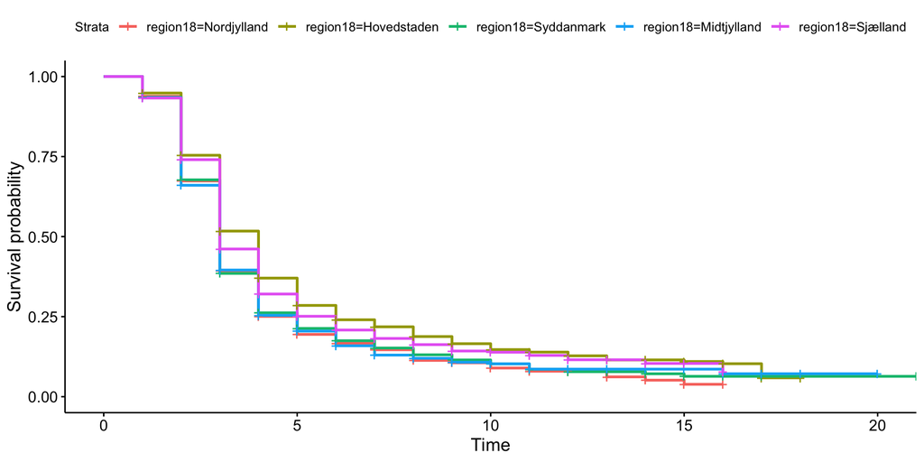

## Kaplan-Meier: log-rank-test

```r
survdiff(Surv(pt_slut, event) ~ region18, data = multi_event2)
```

```
Call:
survdiff(formula = Surv(pt_slut, event) ~ region18, data = multi_event2)

                        N Observed Expected (O-E)^2/E (O-E)^2/V
region18=Nordjylland  536      433      395      3.67      5.74
region18=Hovedstaden 1065      762      883     16.66     31.35
region18=Syddanmark  1038      795      742      3.75      6.64
region18=Midtjylland 1048      798      733      5.85     10.35
region18=Sjælland     715      519      554      2.20      3.65

 Chisq= 44.3  on 4 degrees of freedom, p= 0.000000005
```

1. Vi tester forskelle mellem regionerne med en log-rank-test (`survdiff`).
2. Hvad viser tallene:
   - `Observed` er antallet af faktiske events (fx fødsler) i perioden.
   - `Expected` er antallet af events man ville forvente, hvis der ikke var forskel mellem regioner.
   - $(O-E)^{2}/V$ er bidraget til $\chi^2$-testen fra hver region.
3. `Chisq = 44.3 on 4 degrees of freedom, p = 0.000000005`
   - Testen sammenligner overlevelseskurverne for de 5 regioner.
   - p-værdien er lav: $p < 0.00000001$
   - Det betyder, at der er en signifikant forskel i risikoen for hændelse (`event`) mellem regionerne (i anden periode).

## Kaplan-Meier: tolkning

```r
survdiff(Surv(pt_slut, event) ~ region18, data = multi_event2)
```

```
Call:
survdiff(formula = Surv(pt_slut, event) ~ region18, data = multi_event2)

                        N Observed Expected (O-E)^2/E (O-E)^2/V
region18=Nordjylland  536      433      395      3.67      5.74
region18=Hovedstaden 1065      762      883     16.66     31.35
region18=Syddanmark  1038      795      742      3.75      6.64
region18=Midtjylland 1048      798      733      5.85     10.35
region18=Sjælland     715      519      554      2.20      3.65

 Chisq= 44.3  on 4 degrees of freedom, p= 0.000000005
```

1. Hovedstaden har færre observerede events (762) end forventet (883) $\rightarrow$ lavere risiko for begivenheden $\rightarrow$ mere langsomme overgange (fx længere til næste fødsel).
2. Nordjylland, Midtjylland og Syddanmark har flere observerede events end forventet $\rightarrow$ højere risiko for eventen $\rightarrow$ hurtigere overgange.

> Kaplan-Meier analysen viser signifikante forskelle i tiden til næste fødsel i anden periode på tværs af regioner (log-rank test: $\chi^{2}(4) = 44.3, p < 0.001$). Særligt personer fra Hovedstaden har længere tid mellem fødslerne, mens personer fra Jylland har kortere intervaller.

## Cox-model

```r
cox_v1 <- coxph(Surv(pt_start, pt_slut, event) ~ kvinde + periode_age,
                method = "efron",
                data = multi_all2)
```

## Cox-model: tolkning

```r
summary(cox_v1)
```

```
Call:
coxph(formula = Surv(pt_start, pt_slut, event) ~ kvinde + periode_age,
    data = multi_all2, method = "efron")

  n= 16145, number of events= 3307

                 coef exp(coef)  se(coef)      z Pr(>|z|)
kvinde      -0.026482  0.973865  0.035570 -0.745 0.456563
periode_age  0.016121  1.016252  0.004563  3.533 0.000411 ***
---
Signif. codes:  0 '***' 0.001 '**' 0.01 '*' 0.05 '.' 0.1 ' ' 1

            exp(coef) exp(-coef) lower .95 upper .95
kvinde         0.9739      1.027    0.9083     1.044
periode_age    1.0163      0.984    1.0072     1.025

Concordance= 0.526  (se = 0.006 )
Likelihood ratio test= 14.63  on 2 df,   p=0.0007
Wald test            = 14.61  on 2 df,   p=0.0007
Score (logrank) test = 14.61  on 2 df,   p=0.0007
```

1. Vi undersøger tiden til hændelse (fx fødsel) i anden periode, forklaret ved:
   - `kvinde` (1 = kvinde, 0 = mand).
   - `periode_age` (alder ved start af perioden).
2. Hvad viser data:
   - Antal observationer: 16.145
   - Antal events: 3.307
   - `kvinde: coef = 0.97 p = 0.46, Ikke signifikant → ingen kønseffekt.`
   - `periode_age: coef = 1.016 p = 0.0004, Signifikant → ældre ved start giver en lidt højere risiko.`
3. Tolkning:
   - Kvinder har ca. samme risiko som mænd for at opleve en hændelse i periode 2 (ingen forskel).
   - Jo ældre man er ved start af perioden, desto højere er risikoen (ca. +1.6% per år).

## Cox-model: test af forudsætninger

```r
#http://personal.psu.edu/drh20/R/html/survival/html/cox.zph.html
# transform = "identity" argumentet skal inddrages, når counting process anvendes
(test_cv1 <- cox.zph(cox_v1, transform = "identity"))
```

```
            chisq df     p
kvinde       1.15  1 0.283
periode_age  4.70  1 0.030
GLOBAL       5.13  2 0.077
```

1. Tolkning:
   - `kvinde: p = 0.283 --- Accepteret, ingen tegn på brud.`
   - `periode_age: p = 0.030 --- Mulig afvigelse fra proportionalitet.`
   - `GLOBAL: p = 0.077 --- Samlet set er modellen *næsten* accepteret på 0.05 sig. niveau, men ikke helt.`
2. For `periode_age` kunne det tyde på, at effekten af alder kan ændre sig over tid i periode 2. Vi kunne evt.:
   - Tilføje et interaktionsterm med tid.
   - Stratificere på `periode_age` eller bruge tidsafhængige effekter

> “Cox-regressionen viser, at alder ved periodens start er signifikant forbundet med en øget risiko for hændelse i periode 2 (HR = 1.016, p < 0.001), mens køn ikke har en signifikant effekt. Der er (svage) indikationer på, at proportional hazards-antagelsen ikke er opfyldt for alder.”

## Cox-model: udvidelse

```r
cox_v2 <- coxph(Surv(pt_start, pt_slut, event) ~
                  kvinde + tt(kvinde) + periode_age + tt(periode_age),
                method = "efron",
                data = multi_all2,
                tt = function(x,t,...)x*t)
```

## Cox-model: tolkning

```r
summary(cox_v2)
```

```
Call:
coxph(formula = Surv(pt_start, pt_slut, event) ~ kvinde + tt(kvinde) +
    periode_age + tt(periode_age), data = multi_all2, tt = function(x,
    t, ...) x * t, method = "efron")

  n= 16145, number of events= 3307

                     coef exp(coef)  se(coef)      z Pr(>|z|)
kvinde          -0.066501  0.935662  0.070114 -0.948 0.342894
tt(kvinde)       0.012114  1.012188  0.018404  0.658 0.510382
periode_age      0.033349  1.033912  0.009809  3.400 0.000674 ***
tt(periode_age) -0.005486  0.994529  0.002756 -1.991 0.046479 *
---
Signif. codes:  0 '***' 0.001 '**' 0.01 '*' 0.05 '.' 0.1 ' ' 1

                exp(coef) exp(-coef) lower .95 upper .95
kvinde             0.9357     1.0688    0.8155    1.0735
tt(kvinde)         1.0122     0.9880    0.9763    1.0494
periode_age        1.0339     0.9672    1.0142    1.0540
tt(periode_age)    0.9945     1.0055    0.9892    0.9999

Concordance= 0.527  (se = 0.006 )
Likelihood ratio test= 19.76  on 4 df,   p=0.0006
Wald test            = 19.7  on 4 df,   p=0.0006
Score (logrank) test = 19.71  on 4 df,   p=0.0006
```

1. Vi tester, om effekten af `kvinde` og `periode_age` ændrer sig over tid (altså, om proportional hazards-antagelsen er brudt).
   - `kvinde: 0.936 0.34 Ikke signifikant, ingen kønseffekt`
   - `tt(kvinde) 1.012 0.51 Ikke signifikant, effekt af køn ændrer sig ikke over tid`
   - `periode_age 1.034 0.0007 Signifikant, højere alder ved start er forbundet med højere risiko`
   - `tt(periode_age) 0.995 0.046 Signifikant, alderens effekt aftager over tid`
2. Tolkning:
   - `periode_age` har en signifikant tidsafhængig effekt:
     - $HR < 1$ for `tt(periode_age)` betyder, at jo længere tid der går, desto svagere bliver effekten af alder.
     - Alder betyder mere i starten af perioden og mindre senere.

> “Cox-analysen med tidsafhængige effekter viser, at alder ved periodestart er signifikant forbundet med en øget risiko for hændelse (HR = 1.03, p < 0.001), men effekten aftager over tid (HR for interaktion = 0.995, p = 0.046). Der ses ingen signifikant effekt af køn, og effekten af køn ændrer sig ikke over tid.”

## Cox-model: fuld model

```r
cox_v3 <- coxph(Surv(pt_start, pt_slut, event) ~
                  region18 + kvinde + tt(kvinde) + periode_age + tt(periode_age),
                method = "efron",
                data = multi_all2,
                tt = function(x,t,...)x*t)

summary(cox_v3)
```

```
Call:
coxph(formula = Surv(pt_start, pt_slut, event) ~ region18 + kvinde +
    tt(kvinde) + periode_age + tt(periode_age), data = multi_all2,
    tt = function(x, t, ...) x * t, method = "efron")

  n= 16145, number of events= 3307

                         coef exp(coef)  se(coef)      z  Pr(>|z|)
region18Hovedstaden -0.294091  0.745208  0.060343 -4.874 0.0000011 ***
region18Syddanmark  -0.030566  0.969897  0.059754 -0.512  0.608979
region18Midtjylland -0.015456  0.984662  0.059727 -0.259  0.795802
region18Sjælland    -0.190103  0.826874  0.065211 -2.915  0.003555 **
kvinde              -0.051483  0.949819  0.070289 -0.732  0.463890
tt(kvinde)           0.011826  1.011897  0.018465  0.640  0.521862
periode_age          0.035069  1.035691  0.009851  3.560  0.000371 ***
tt(periode_age)     -0.005563  0.994453  0.002763 -2.013  0.044069 *
---
Signif. codes:  0 '***' 0.001 '**' 0.01 '*' 0.05 '.' 0.1 ' ' 1

                    exp(coef) exp(-coef) lower .95 upper .95
region18Hovedstaden    0.7452     1.3419    0.6621    0.8388
region18Syddanmark     0.9699     1.0310    0.8627    1.0904
region18Midtjylland    0.9847     1.0156    0.8759    1.1069
region18Sjælland       0.8269     1.2094    0.7277    0.9396
kvinde                 0.9498     1.0528    0.8276    1.0901
tt(kvinde)             1.0119     0.9882    0.9759    1.0492
periode_age            1.0357     0.9655    1.0159    1.0559
tt(periode_age)        0.9945     1.0056    0.9891    0.9999

Concordance= 0.552  (se = 0.007 )
Likelihood ratio test= 67  on 8 df,   p=0.00000000002
Wald test            = 65.79  on 8 df,   p=0.00000000003
Score (logrank) test = 66.03  on 8 df,   p=0.00000000003
```

> “Risikoen for hændelse i anden periode varierer signifikant mellem regioner. Unge fra Hovedstaden og Sjælland har lavere risiko sammenlignet med unge fra Nordjylland (HR = 0.75 og 0.83, begge signifikante). Der er ingen signifikant forskel mellem de øvrige regioner. Alder ved periodestart er positivt associeret med hændelse (HR = 1.036, p < 0.001), men effekten aftager svagt over tid (HR for interaktion = 0.994, p = 0.044). Køn har ingen signifikant effekt, og effekten ændrer sig ikke over tid.”

## AFT model

```r
aft1 <- survreg(Surv(pt_slut, event) ~ kvinde + periode_age + region18,
                dist = c("weibull"),
                data = multi_event2)

aft2 <- survreg(Surv(pt_slut, event) ~ kvinde + periode_age + region18,
                dist = c("exponential"),
                data = multi_event2)

aft3 <- survreg(Surv(pt_slut, event) ~ kvinde + periode_age + region18,
                dist = c("lognormal"),
                data = multi_event2)

aft4 <- survreg(Surv(pt_slut, event) ~ kvinde + periode_age + region18,
                dist = c("loglogistic"),
                data = multi_event2)
```

## AFT: udvælg bedste model

```r
extractAIC(aft1)[2]
```

```
[1] 16105.78
```

```r
extractAIC(aft2)[2]
```

```
[1] 17066.48
```

```r
extractAIC(aft3)[2]
```

```
[1] 15084.42
```

```r
extractAIC(aft4)[2]
```

```
[1] 15000.4
```

> “Sammenligning af fire AFT-modeller med forskellige fordelinger viser, at en loglogistisk (aft4) fordeling giver det bedste model-fit (AIC = 15000.4). Dette tyder på, at risikoen for hændelse ikke følger en konstant eller monotont stigende/faldende hazardrate, men snarere varierer over tid.”

## AFT: tolkning

```r
summary(aft4)
```

```
Call:
survreg(formula = Surv(pt_slut, event) ~ kvinde + periode_age +
    region18, data = multi_event2, dist = c("loglogistic"))
                       Value Std. Error      z                    p
(Intercept)          1.62902    0.08515  19.13 < 0.0000000000000002
kvinde               0.01732    0.02050   0.84               0.3982
periode_age         -0.01686    0.00273  -6.17         0.0000000007
region18Hovedstaden  0.17131    0.03475   4.93         0.0000008219
region18Syddanmark   0.00615    0.03440   0.18               0.8581
region18Midtjylland -0.00478    0.03424  -0.14               0.8890
region18Sjælland     0.09646    0.03736   2.58               0.0098
Log(scale)          -1.00474    0.01448 -69.39 < 0.0000000000000002

Scale= 0.366

Log logistic distribution
Loglik(model)= -7492.2   Loglik(intercept only)= -7538.2
    Chisq= 91.94 on 6 degrees of freedom, p= 0.000000000000000012
Number of Newton-Raphson Iterations: 3
n= 4402
```

## Discret-tid model

```r
d_log <- glm(event ~ region18 + kvinde + periode_age + as.factor(slut),
             data = multi_event2,
             family = binomial(link = logit))
```

## Discret-tid model: tolkning

```r
summary(d_log)
```

```
Call:
glm(formula = event ~ region18 + kvinde + periode_age + as.factor(slut),
    family = binomial(link = logit), data = multi_event2)

Coefficients:
                     Estimate Std. Error z value   Pr(>|z|)
(Intercept)           1.89140    1.10394   1.713   0.086654 .
region18Hovedstaden  -0.22636    0.14858  -1.523   0.127648
region18Syddanmark   -0.21048    0.15067  -1.397   0.162443
region18Midtjylland  -0.26348    0.15022  -1.754   0.079439 .
region18Sjælland     -0.39470    0.15841  -2.492   0.012718 *
kvinde               -0.05267    0.08214  -0.641   0.521359
periode_age           0.02978    0.01465   2.033   0.042070 *
as.factor(slut)4     14.34691  536.13073   0.027   0.978651
as.factor(slut)5      1.52962    1.46171   1.046   0.295351
as.factor(slut)6      1.78740    1.46021   1.224   0.220923
as.factor(slut)7     14.29402  240.82857   0.059   0.952671
as.factor(slut)8      2.36179    1.45769   1.620   0.105183
as.factor(slut)9      1.63982    1.20700   1.359   0.174278
as.factor(slut)10     2.22244    1.27460   1.744   0.081223 .
as.factor(slut)11     1.18285    1.12627   1.050   0.293607
as.factor(slut)12     1.54701    1.13751   1.360   0.173831
as.factor(slut)13    -1.22503    1.06778  -1.147   0.251270
as.factor(slut)14    -1.18588    1.06918  -1.109   0.267367
as.factor(slut)15    -1.23402    1.07158  -1.152   0.249491
as.factor(slut)16    -1.49402    1.07273  -1.393   0.163701
as.factor(slut)17    -1.83195    1.07535  -1.704   0.088459 .
as.factor(slut)18    -1.91038    1.07752  -1.773   0.076238 .
as.factor(slut)19    -2.53982    1.07912  -2.354   0.018593 *
as.factor(slut)20    -2.89828    1.08507  -2.671   0.007561 **
as.factor(slut)21    -3.57160    1.09020  -3.276   0.001052 **
as.factor(slut)22    -3.74238    1.09575  -3.415   0.000637 ***
as.factor(slut)23    -5.60052    1.18862  -4.712 0.00000246 ***
---
Signif. codes:  0 '***' 0.001 '**' 0.01 '*' 0.05 '.' 0.1 ' ' 1

(Dispersion parameter for binomial family taken to be 1)

    Null deviance: 4938.7  on 4401  degrees of freedom
Residual deviance: 3735.2  on 4375  degrees of freedom
AIC: 3789.2

Number of Fisher Scoring iterations: 15
```

Jeppe F. Qvist | 1. maj 2025